# Seminar 4 (uke 10): Mundell-Fleming og AD ligningen under fast og flytende kurs

## Åpen økonomi

1. Hvilke virkemidler har myndighetene for å stabilisere konjunkturene under henholdsvis et fast og flytende kurs regime?

*Fast kurs: Endringer i offentlige utgifter (G), Endringer i skatter (T)* *Flytende kurs: Endringer i offentlige utgifter (G), Endringer i skatter (T) og Pengepolitikk (M/(i))*

2. Hva menes med intern og ekstern balanse?

*Intern balanse: Produksjonsgapet er lukket $(Y-Y^{*})=0$*

*Ekstern balanse: Utenlandsgjelden er på et bærekraftig nivå (kan betjenes uten problemer)*

3. Hva menes med en liten åpen økonomi?

*Liten: Det som skjer i utlandet påvirker landets økonomi, men ikke omvendt*

*Åpner: Handler med andre land i form av import og eksport av varer og tjenester*

4. Vis at partietsbetingelsen kan omformuleres til:

*Paritetsbetingelsen er gitt ved: $(1+i)=(1+i^{*})E^{e}/E$*

*Her løser vi bare denne mhp på E (endogen):*
$$E=\frac{(1+i^{*})}{(1+i)}E^{e}\text{ flytende kurs}$$

*Starter her med å sette inn for at $E^e=E$ (troverdig kurs). Paritetsbetingelsen kan derfor forenkles til*

$$i=i^{*} \text{ fast kurs (troverdig)}$$

5. Gi en økonomisk tolkning på hva som skjer i de to regimene dersom denne betingelsen ikke holder med likhet?

*Flytende kurs: $E>\frac{(1+i^{*})}{(1+i)}E^{e} \Leftrightarrow (1+i)>\frac{E^{e}}{E}(1+i^{*})$*

*Høyere avkastning av å investere i innlandet sammenlignet med utlandet. Investorene vil derfor reallokere sine portefølje ved å plassere mer i norsk valuta. Dette vil øke etterspørselen etter norske kroner, og med det presse kronekursen oppover (appresiering) inntil betingelsen igjen er oppfylt med likhet. Resonnementet bli motsatt dersom ulikheten er gitt ved <.*

*Fast kurs: $i>i^{*}$*

## Mundell-Fleming modellen

Vi benyttter samme modell som gitt under seminar 2 og 3:
$$C = \overline{C} + c_{1}(Y-T) - c_{2}\cdot i \text{ :husholdningen}$$
$$I = \overline{I} - b\cdot i \text{ :private realinvesteringer}$$
$$G = \overline{G} \text{ og } T=\overline{T} \text{: offentlige myndigheter}$$
$$EX = x_{1}\cdot R + x_{2}\cdot Y^{*} \text{: eksport}$$
$$IM= - m_{1}\cdot R + m_{2}\cdot Y \text{: import}$$

$$NX = EX - R\cdot IM \text{: nettoeksport}$$
$$kY -hi = \overline{M}/P \text{: fra pengemarkedet}$$
I tillegg antar vi at udekket renteparitet holder:

$$(1+i)=(1+i^{*})E^{e}/E$$

### Samtidig likevekt

6. Løs for likevektsbetingelsene under hhv. fast og flytende kurs og vis grafisk den samtidige likevekten
- Fast kurs:

*$$kY -hi = M/P \text{ :pengemarkedet (passiv)}$$*

*$$i = i^{*} + rp$$*

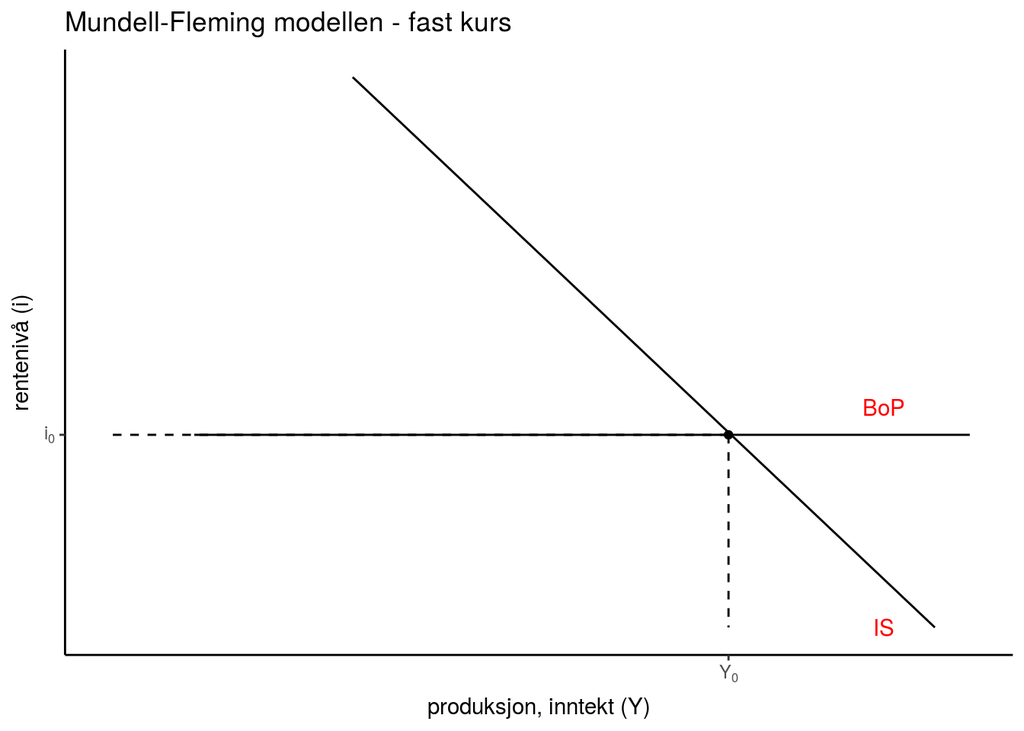

- Flytende kurs IS-BoP ligningen kan vi finne ved å kombinere løsningen for valuta- og godemarkedet:

*$E=E(i,i^{*},E^{e}) \Rightarrow R = \frac{E(i,i^{*},E^{e})\cdot P^{*}}{P}=R(E(i,i^{*},E^{e}),P,P^{*}) = R(\cdot)$ Setter vi inn for $R(\cdot)$ godemarkedet får vi:*

*$$Y = \frac{1}{1-c_{1} + R(\cdot) m_{2}} \left [ \overline{C} - c_{1}\overline{T} + \overline{I} - i\cdot(b+c_{2}) + \overline{G} + EX\Big( R(\cdot) \Big) + R(\cdot)^{2}\cdot m_{1} \right] \text{: godemarkedet}$$*

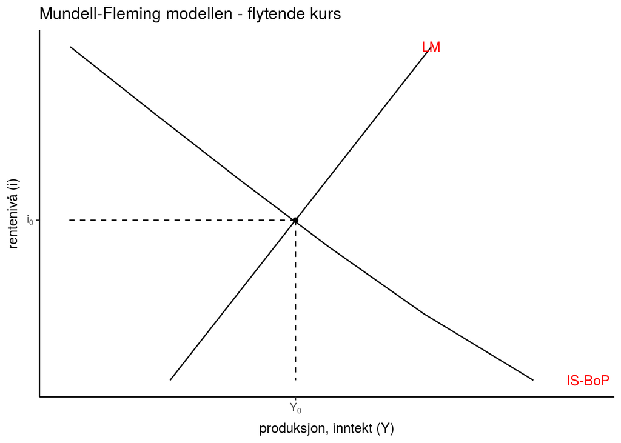

7. Hvor er helningen på IS-BoP ligningen (flytende kurs) slakere enn IS-kurven?

*Det skyldes at en lavere (høyere) rente gir en depresiering (appresiering) av valutakursen som følge av udekke renteparitet (see oppgave). Økt depresiering bidrar til en svekkelse av realvalutakursen som gir en økningen i nettoeksporten (Marshall-Lerner betingelsen). Det er denne etterspørselsøkningen (som ikke er med i fast-kurs regimet) som gjør at kurven blir slakere*

8. Under et flytende kurs regime, se for deg en situasjon med økte private realinvesteringer $\Delta I>0$ (‘animal spirits’) som etterhvert motvirket av en kontraktiv pengepolitikk og illustrer dette grafisk et diagram ved bruk av Mundell-Fleming modellen.

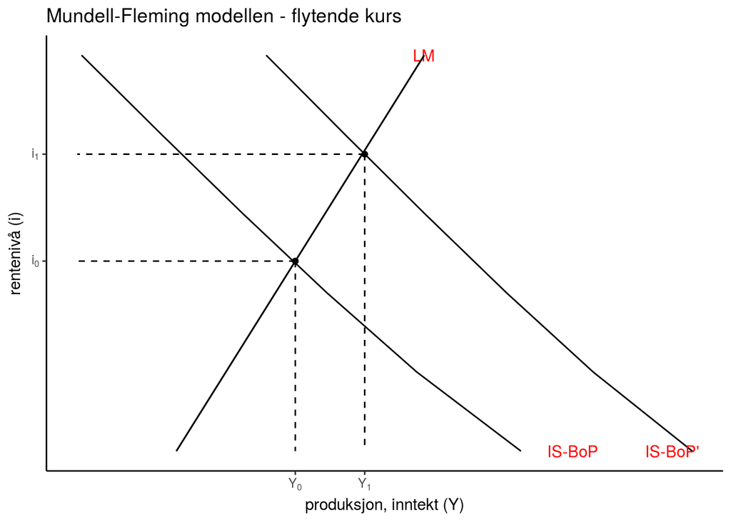

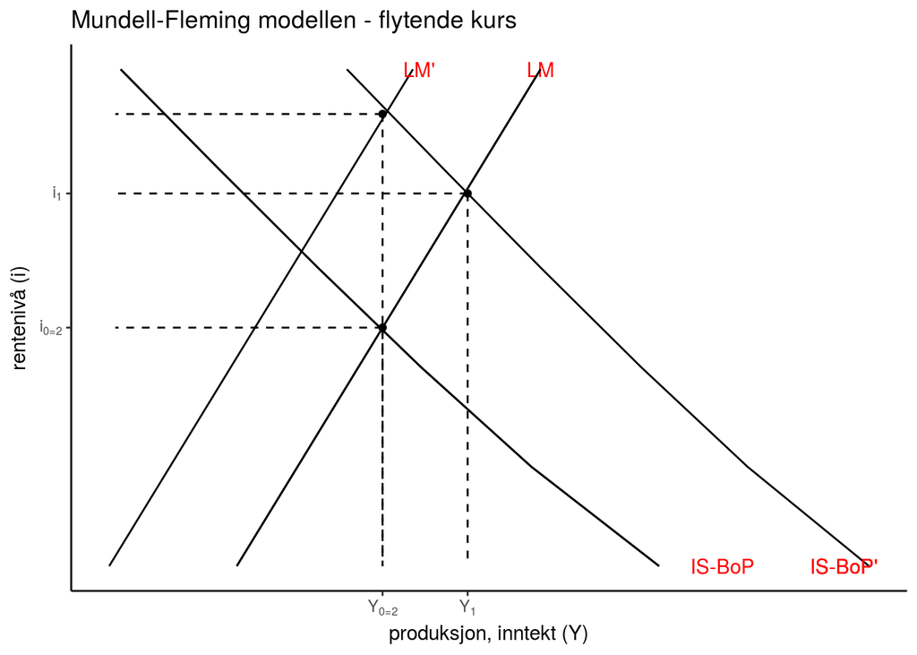

# AD-kurven

9. Vis og forklar hvorfor AD-kurven er fallende under et fast og flytende kurs regime.

*Fast kurs:*

*(1) Økt nettoeksport: Lavere produktpriser fører til en en svekkelse (depresiering) av realvalutakursen som gir en etterspørselsøkning gjennom en økningen i nettoeksporten (Marshall-Lerner betingelsen). Den økte etterspørselen initierer en positiv multiplikatoreffekt, ifølge mekanismene som gjelder for Keynes-modellen for en åpen økonomi.*

*Flytende kurs:*

*(1) Økt nettoeksport: Lavere produktpriser fører til en en svekkelse (depresiering) av realvalutakursen som gir en etterspørselsøkning gjennom en økningen i nettoeksporten (Marshall-Lerner betingelsen). Den økte etterspørselen initierer en positiv multiplikatoreffekt, ifølge mekanismene som gjelder for Keynes-modellen for en åpen økonomi.*

*Se forelesningsnotatene for grafisk løsning*